# Final Project Prototype: Deep Learning Algorithm to Recognize Spoilers

In order to show proof of concept, I have developed a deep learning bag-of-words algorithm as my prototype. Deep learning allows for pattern recognition in words, sentences, and paragraphs, meaning it can be applied to this project in order to classify whether a piece of text includes a spoiler or not.

My development process can be examined through this notebook. I have included explanations and justification in text cells in-between the code to show my understand and demonstrate how I will continue the development phase moving forward.

# Part 1: Kaggle & Dataset

As the first step, I am preparing the notebook by installing Kaggle and then the dataset.

## 1.1: Installing Kaggle

I have installed Kaggle using the following commands. While the output shows "already satisfied", thanks to Google Colab, I am leaving the code here for good practice, as it could be needed when running this notebook on a different platform.

I have generated an API login using my Kaggle account and uploaded the JSON file, `kaggle.json`, containing the username and key, to this notebook. If running this notebook, and not viewing via the HTML format, the API key, included in the submission folder, needs to be uploaded to the notebook before running the first code cell.

```python
# installing kaggle library
! pip install kaggle

# making kaggle directory
! mkdir ~/.kaggle

# copying api login info into directory
! cp kaggle.json ~/.kaggle/

# allocating required permissions
! chmod 600 ~/.kaggle/kaggle.json
```

```
mkdir: cannot create directory ‘/root/.kaggle’: File exists
```

## 1.2: Installing Dataset

The dataset used for this prototype and any further iterations of this model is the IMDB Spoiler Dataset, downloaded from Kaggle. This dataset was developed using IMDB and contains two different databases: movies and reviews. The reviews dataset, which will be the one used for this model, contains 573,913 records.

IMDB allows users to know which reviews contain spoilers by tagging the reviews with "Warning: Spoilers". Reviews which include spoilers but have not been indicated to do so by the reviewer will be removed when reported under the "Spoiler without warning" option. Due to this, I can be confident that this dataset includes accurate information, making this dataset was the best option for the project; the only downside is that the reviews are only taken from movies, and not a mix of movies and TV shows, which would have been more applicable to this project.

In the code cell below, I am downloading the dataset from Kaggle and unzipping it to make the data accessible.

```python
! kaggle datasets download rmisra/imdb-spoiler-dataset

# unzipping dataset
! unzip imdb-spoiler-dataset.zip
```

```
Downloading imdb-spoiler-dataset.zip to /content
 97% 323M/331M [00:10<00:00, 42.6MB/s]
100% 331M/331M [00:10<00:00, 33.5MB/s]
Archive:  imdb-spoiler-dataset.zip
  inflating: IMDB_movie_details.json
  inflating: IMDB_reviews.json
```

### 1.2.1: Reviews Database

As mentioned above, the database I will be using from this dataset is the reviews database, which has over five hundred thousand reviews. This database contains information about each review, such as the date it was made, the movie ID of the movie it was about, the review text itself and a boolean field which indicates whether or not it is a spoiler.

```python
# importing pandas to read the JSON files
import pandas as pd

# information regarding reviews file
all_reviews = pd.read_json('../content/IMDB_reviews.json', lines=True)

print('Total number of reviews:', all_reviews['review_date'].count())
print('Total number of reviews that contain spoilers:', all_reviews['is_spoiler'].sum())
print('User reviews shape:', all_reviews.shape)
print()

print('First 5 user reviews:')
all_reviews.head()
```

```
Total number of reviews: 573913
Total number of reviews that contain spoilers: 150924
User reviews shape: (573913, 7)

First 5 user reviews:
```

|  | review_date | movie_id | user_id | is_spoiler | review_text | rating | review_summary |
| --- | --- | --- | --- | --- | --- | --- | --- |
| 0 | 10 February 2006 | tt0111161 | ur1898687 | True | In its Oscar year, Shawshank Redemption (writt... | 10 | A classic piece of unforgettable film-making. |
| 1 | 6 September 2000 | tt0111161 | ur0842118 | True | The Shawshank Redemption is without a doubt on... | 10 | Simply amazing. The best film of the 90's. |
| 2 | 3 August 2001 | tt0111161 | ur1285640 | True | I believe that this film is the best story eve... | 8 | The best story ever told on film |
| 3 | 1 September 2002 | tt0111161 | ur1003471 | True | **Yes, there are SPOILERS here**This film has ... | 10 | Busy dying or busy living? |
| 4 | 20 May 2004 | tt0111161 | ur0226855 | True | At the heart of this extraordinary movie is a ... | 8 | Great story, wondrously told and acted |

### 1.2.2: Movies Database

The second database included in this dataset is the movies database. This database contains all the information regarding each movie itself, such as the genre, duration, and release date. Information about this database and a sample of the first 5 movies can be seen below.

```python
# information regarding movie details file
all_movies = pd.read_json('../content/IMDB_movie_details.json', lines=True)

print('Total number of movies:', all_movies['movie_id'].count())
print('Movie details shape:', all_movies.shape)
print()

print('First 5 movie details:')

all_movies.head()
```

```
Total number of movies: 1572
Movie details shape: (1572, 7)

First 5 movie details:
```

|  | movie_id | plot_summary | duration | genre | rating | release_date | plot_synopsis |
| --- | --- | --- | --- | --- | --- | --- | --- |
| 0 | tt0105112 | Former CIA analyst, Jack Ryan is in England wi... | 1h 57min | [Action, Thriller] | 6.9 | 1992-06-05 | Jack Ryan (Ford) is on a "working vacation" in... |
| 1 | tt1204975 | Billy (Michael Douglas), Paddy (Robert De Niro... | 1h 45min | [Comedy] | 6.6 | 2013-11-01 | Four boys around the age of 10 are friends in ... |
| 2 | tt0243655 | The setting is Camp Firewood, the year 1981. I... | 1h 37min | [Comedy, Romance] | 6.7 | 2002-04-11 |  |
| 3 | tt0040897 | Fred C. Dobbs and Bob Curtin, both down on the... | 2h 6min | [Adventure, Drama, Western] | 8.3 | 1948-01-24 | Fred Dobbs (Humphrey Bogart) and Bob Curtin (T... |
| 4 | tt0126886 | Tracy Flick is running unopposed for this year... | 1h 43min | [Comedy, Drama, Romance] | 7.3 | 1999-05-07 | Jim McAllister (Matthew Broderick) is a much-a... |

# Part 2: Processing the data

The data needs to be processed before a model can be built. Here I will be loading the reviews and the spoiler labels into lists tokenizing using one-hot encoding, and splitting the dataset into training, validation and testing sets.

## 2.1: Loading the data

Here the labels are being added to a `labels` list while the review text is being added to a `texts` list.

```python
import json

labels = []
texts = []

with open('IMDB_reviews.json', 'r') as json_file:
  for jsonObj in json_file:
    data = json.loads(jsonObj)
    if data['is_spoiler'] == True:
       labels.append(1)
    else:
       labels.append(0)
    texts.append(data['review_text'])
```

## 2.2: Tokenizing the text

Before splitting, I am tokenizing the text data using one-hot encoding. To do this I am using the `Tokenizer` module from Keras.

I have cut the reviews of after a maximum of 500 words and am only considering the most frequent 15000 words in the dataset.

After tokenizing, I have vectorized the data using the `pad_sequences` module from Keras, which converts the list of tokenized data, integers, into 2D tensors, which can then be fed into the neural network. I have also vectorized the list of labels by converting it to a list of floating point numbers.

```python
from keras.preprocessing.text import Tokenizer
from keras.preprocessing.sequence import pad_sequences
import numpy as np

maxlen = 500 # cuts reviews off after 500 words
max_words = 15000 # considers only the top 15000 words in the dataset

# tokenizing texts
tokenizer = Tokenizer(num_words=max_words)
tokenizer.fit_on_texts(texts)
sequences = tokenizer.texts_to_sequences(texts)
word_index = tokenizer.word_index
print('Found %s unique tokens.' % len(word_index))

# vectorizing texts
data = pad_sequences(sequences, maxlen=maxlen)

# vectorizing labels
labels = np.asarray(labels).astype('float32')

print('Shape of data tensor:', data.shape)
print('Shape of label tensor:', labels.shape)
```

```
Found 379856 unique tokens.
Shape of data tensor: (573913, 500)
Shape of label tensor: (573913,)
```

## 2.3: Splitting Data

Initially, I am splitting the dataset into training and testing sets. This way I will be testing the model on unseen data only, ensuring information leaking does not affect the final results.

I am first shuffling the data, since the JSON file lists all reviews including spoilers first, then splitting it. I will be training on 200,000 samples and testing using 100.000 for this prototype.

```python
# suffling data
indices = np.arange(data.shape[0])
np.random.shuffle(indices)
data = data[indices]
labels = labels[indices]

# setting number of training and testing samples
training_samples = 200000
testing_samples = 100000

# splitting into training and testing sets
x_train = data[:training_samples]
y_train = labels[:training_samples]
x_test = data[training_samples: training_samples + testing_samples]
y_test = labels[training_samples: training_samples + testing_samples]
```

```python
print('Training data shape:',x_train.shape)
print('Training labels shape:', y_train.shape)

print('Test data shape:',x_test.shape)
print('Test labels shape:',y_test.shape)
```

```
Training data shape: (200000, 500)
Training labels shape: (200000,)
Test data shape: (100000, 500)
Test labels shape: (100000,)
```

I am then further splitting the training set into a partial training and validation set. This way the data used to validate will not be the same as that used to train, which could cause the model to overfit. I will be training on 150,000 samples and validating on 50,000.

```python
# setting number of training and validation samples
partial_training_samples = 150000
validation_samples = 50000

# splitting into training and validation sets
x_partial_train = data[:partial_training_samples]
y_partial_train = labels[:partial_training_samples]
x_val = data[partial_training_samples: partial_training_samples + validation_samples]
y_val = labels[partial_training_samples: partial_training_samples + validation_samples]
```

```python
print('Partial training data shape:',x_partial_train.shape)
print('Partial training labels shape:', y_partial_train.shape)

print('Validation data shape:',x_val.shape)
print('Validation labels shape:',y_val.shape)
```

```
Partial training data shape: (150000, 500)
Partial training labels shape: (150000,)
Validation data shape: (50000, 500)
Validation labels shape: (50000,)
```

# Part 3: The Initial Model

Here I am developing the initial model, which I will then tune.

## 3.1: Defining Initial Model

The initial model I've defined can be seen below. This model consists of 6 layers.

The first two layers are used for word embeddings, which is used to map human language into a geometric space. The `Embedding` layer takes integers as input, finds the integer in an internal dictionary, and returns corresponding word vectors, allowing for vectors to be associated with words.

The next four layers are classification layers, the last being an output layer.

```python
from tensorflow.keras import models
from tensorflow.keras import layers
from keras.layers import Embedding, Flatten

model = models.Sequential()

# Embedding layers
# network will learn 8-dimensional embeddings for each of the 15,000 words
model.add(Embedding(15000, 8, input_length=maxlen))
# flattens the 3D tensor output to a 2D tensor
model.add(Flatten())

# training single dense layer for classfication
model.add(layers.Dense(128, activation = 'relu'))
model.add(layers.Dense(64, activation = 'relu'))
model.add(layers.Dense(32, activation = 'relu'))

# output layer
model.add(layers.Dense(1, activation = 'sigmoid'))

model.compile(optimizer = 'rmsprop',
              loss = 'binary_crossentropy',
              metrics = ['accuracy'])

model.build()
model.summary()
```

```
Model: "sequential_11"
_________________________________________________________________
 Layer (type)                Output Shape              Param #
=================================================================
 embedding_11 (Embedding)    (None, 500, 8)            120000

 flatten_11 (Flatten)        (None, 4000)              0

 dense_37 (Dense)            (None, 128)               512128

 dense_38 (Dense)            (None, 64)                8256

 dense_39 (Dense)            (None, 32)                2080

 dense_40 (Dense)            (None, 1)                 33

=================================================================
Total params: 642,497
Trainable params: 642,497
Non-trainable params: 0
_________________________________________________________________
```

## 3.2: Training Initial Model

Here I have trained the initial model using the partial training data and validated it on the validation data. I have trained for 10 epochs with a batch size of 32.

```python
history = model.fit(x_partial_train, y_partial_train,
                    epochs = 10,
                    batch_size = 32,
                    validation_data = (x_val, y_val))
```

```python
history_dict = history.history
history_dict.keys()
```

```
dict_keys(['loss', 'accuracy', 'val_loss', 'val_accuracy'])
```

## 3.3: Results

Here I am plotting the results of my initial model to show this method does prove the concept of this project; being able to recognize spoilers in text.

### 3.3.1: Loss

Below you can see a plot showing the training and validation loss. This plot shows the training loss decreasing after every epoch, while the validation loss increases. Specifically, the validation loss seems to increase significantly after the second epoch.

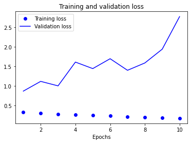

```python
import matplotlib.pyplot as plt

def plot_loss(history_dict):
  plt.clf() # clears existing figures

  loss = history_dict['loss']
  val_loss = history_dict['val_loss']

  epochs = range(1, len(loss) + 1)

  plt.plot(epochs, loss, 'bo', label='Training loss')
  plt.plot(epochs, val_loss, 'b', label='Validation loss')
  plt.title('Training and validation loss')
  plt.xlabel('Epochs')
  plt.legend()

  plt.show()

plot_loss(history_dict)
```

### 3.3.2: Accuracy

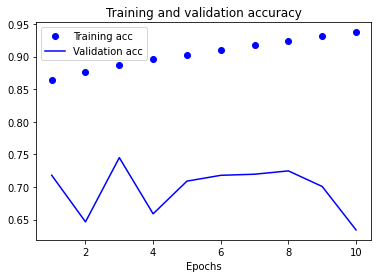

```python
def plot_acc(history_dict):
  plt.clf() # clears existing figures

  acc = history_dict['accuracy']
  val_acc = history_dict['val_accuracy']

  epochs = range(1, len(acc) + 1)

  plt.plot(epochs, acc, 'bo', label='Training acc')
  plt.plot(epochs, val_acc, 'b', label='Validation acc')

  plt.title('Training and validation accuracy')
  plt.xlabel('Epochs')
  plt.legend()

  plt.show()

plot_acc(history_dict)
```

Moving forward, I will try a range of techniques to combat the overfitting issues.

# Part 4: Tuning & Regualizing

Here I am tuning the learning rate and adding regularization to achieve the highest possible accuracy.

## 4.1: Learning Rate

I am tuning the learning rate of the optimiser. The learning rate determines how much the weights of the network are updated according to the accuracy achieved. If the learning rate is too small, the model may never find the optimal set of weights as they will be updated in very small amounts. If it is too large, the optimal set of weights could get skipped over during training.

As I will be building many iterations of this model, I have made a `build_model` and `train_model` function to make this process more efficient, shown below.

```python
from tensorflow.keras import optimizers

def build_model(learning_rate):
  model = models.Sequential()

  # Embedding layers
  model.add(Embedding(15000, 8, input_length=maxlen))
  # flattens the 3D tensor output to a 2D tensor
  model.add(Flatten())

  # training single dense layer for classfication
  model.add(layers.Dense(128, activation = 'relu'))
  model.add(layers.Dense(64, activation = 'relu'))
  model.add(layers.Dense(32, activation = 'relu'))

  # outup layer
  model.add(layers.Dense(1, activation = 'sigmoid'))

  model.compile(optimizer=optimizers.RMSprop(learning_rate=learning_rate),
              loss = 'binary_crossentropy',
              metrics = ['accuracy'])

  return model

def train_model(learning_rate):
  model = build_model(learning_rate)
  history = model.fit(x_partial_train, y_partial_train,
                    epochs = 10,
                    batch_size = 32,
                    validation_data = (x_val, y_val))

  return history.history
```

### Model 1: Learning Rate 0.005

```python
model_1 = train_model(0.005)
```

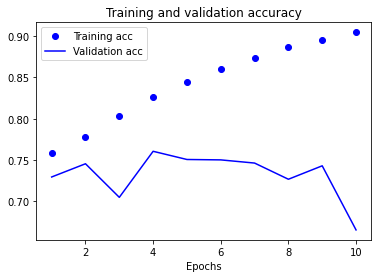

```python
plot_acc(model_1)
```

### Model 2: Learning Rate 0.003

```python
model_2 = train_model(0.003)
```

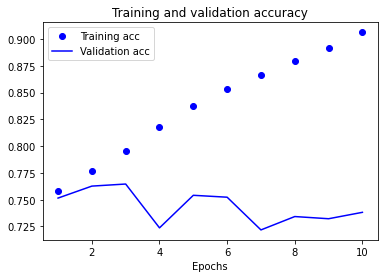

```python
plot_acc(model_2)
```

### Model 3: Learning Rate 0.0005

```python
model_3 = train_model(0.0005)
```

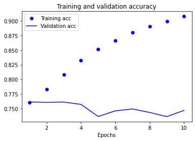

```python
plot_acc(model_3)
```

### Results

The tale below shows the results in terms of highest validation accuracy achieved by different learning rates.

[output not shown]

## 4.2: Weight Regularization

I am adding weight regularization, where the network is forced to set weights to small values, making the distribution of them more regular. This is done by adding a cost to the loss function for larger weights. There are two types of costs:

1. L1 regularization: This is where the cost added to the weight is equivalent to the absolute value of the weight coefficients.
2. L2 regularization: This is where the cost added to the weight is equivalent to the square of the weight coefficients.

These two types of costs can be added to a network individually or simultaneously. I will be testing all three methods to find the one that works best for this model. In order to implement regularizers I have imported the regularizers module from Keras, shown below. I have also made a new build function to train the models.

```python
from keras import regularizers

def train_reg_model(model):
  history = model.fit(x_partial_train, y_partial_train,
                    epochs = 10,
                    batch_size = 32,
                    validation_data = (x_val, y_val))

  return history.history
```

### Model 4: L1 Regularization

```python
model = models.Sequential()
model.add(Embedding(15000, 8, input_length=maxlen))
model.add(Flatten())
model.add(layers.Dense(128, kernel_regularizer=regularizers.l1(0.001), activation = 'relu'))
model.add(layers.Dense(64, kernel_regularizer=regularizers.l1(0.001), activation = 'relu'))
model.add(layers.Dense(32, kernel_regularizer=regularizers.l1(0.001),activation = 'relu'))


model.add(layers.Dense(1, activation = 'sigmoid'))

model.compile(optimizer = 'rmsprop',
              loss = 'binary_crossentropy',
              metrics = ['accuracy'])

model.build()

model_4 = train_reg_model(model)
```

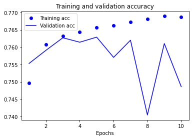

```python
plot_acc(model_4)
```

### Model 5: L2 Regulaization

The second model I am training implements L2 regularization. This model peaks at epoch 3, to 0.766.

```python
model = models.Sequential()
model.add(Embedding(15000, 8, input_length=maxlen))
model.add(Flatten())
model.add(layers.Dense(128, kernel_regularizer=regularizers.l2(0.001), activation = 'relu'))
model.add(layers.Dense(64, kernel_regularizer=regularizers.l2(0.001), activation = 'relu'))
model.add(layers.Dense(32, kernel_regularizer=regularizers.l2(0.001),activation = 'relu'))


model.add(layers.Dense(1, activation = 'sigmoid'))

model.compile(optimizer = 'rmsprop',
              loss = 'binary_crossentropy',
              metrics = ['accuracy'])

model.build()

model_5 = train_reg_model(model)
```

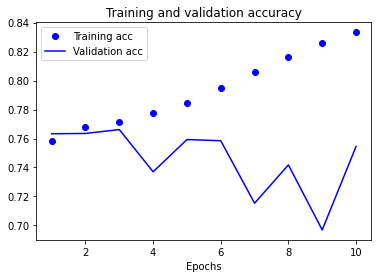

```python
plot_acc(model_5)
```

### Model 6: L1 & L2 Regulaization

The last model I am implementing includes L1 and L2 regularization simultaneously. This model achieved a highest validation accuracy of 0.765 at epoch 8.

```python
model = models.Sequential()
model.add(Embedding(15000, 8, input_length=maxlen))
model.add(Flatten())
model.add(layers.Dense(128, kernel_regularizer=regularizers.l1_l2(l1=0.001, l2=0.001), activation = 'relu'))
model.add(layers.Dense(64, kernel_regularizer=regularizers.l1_l2(l1=0.001, l2=0.001), activation = 'relu'))
model.add(layers.Dense(32, kernel_regularizer=regularizers.l1_l2(l1=0.001, l2=0.001),activation = 'relu'))


model.add(layers.Dense(1, activation = 'sigmoid'))

model.compile(optimizer = 'rmsprop',
              loss = 'binary_crossentropy',
              metrics = ['accuracy'])

model.build()

model_6 = train_reg_model(model)
```

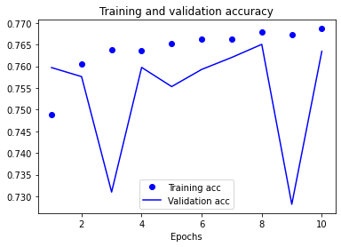

```python
plot_acc(model_6)
```

### Results

The table below shows the results in terms of highest validation accuracy achieved by adding different weight regularizers.

[output not shown]

As seen in the table, the model with L2 regulaization achieved the highest validation accuracy, at 0.766, however this was not significantly higher than any other model, with the biggest difference being 0.004, so I will not be including weight regulaization in models moving forward.

## 4.4: Dropout

Dropout is another regularizing technique which I will be implementing. It drops, i.e., sets to zero, a number of output features of a model during training, breaking apart coincidental patterns that aren’t significant, allowing the final model to be more generalisable. I have remade the build_model and train_model functions, shown below.

```python
def build_drop_model(dropout):
  model = models.Sequential()
  model.add(Embedding(15000, 8, input_length=maxlen))
  model.add(Flatten())
  model.add(layers.Dense(128, activation = 'relu'))
  model.add(layers.Dropout(dropout)) # dropout layer
  model.add(layers.Dense(64, activation = 'relu'))
  model.add(layers.Dropout(dropout)) # dropout layer
  model.add(layers.Dense(32, kernel_regularizer=regularizers.l2(0.001),activation = 'relu'))
  model.add(layers.Dense(1, activation = 'sigmoid'))

  model.compile(optimizer = 'rmsprop',
              loss = 'binary_crossentropy',
              metrics = ['accuracy'])

  return model

def train_drop_model(dropout):
  model = build_drop_model(dropout)
  history = model.fit(x_partial_train, y_partial_train,
                    epochs = 10,
                    batch_size = 32,
                    validation_data = (x_val, y_val))

  return history.history
```

### Model 7: Dropout 30%

I am stating by adding a dropout rate of 30% to two layers in the model. This has not significantly changed the highest validation accuracy, which is still at 0.765. This could be because the dropout rate was either too high or too low.

```python
model_7 = train_drop_model(0.3)
```

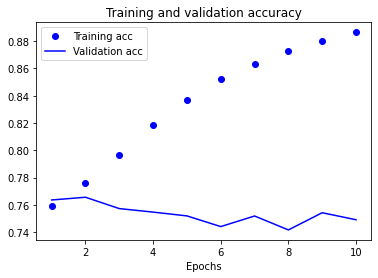

```python
plot_acc(model_7)
```

### Model 8: Dropout 20%

I have dropped the dropout rate to 20% for the next model. This has increased the highest validation accuracy to 0.767 at epoch 2.

```python
model_8 = train_drop_model(0.2)
```

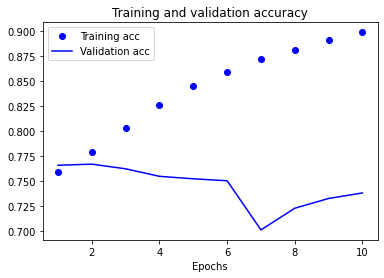

```python
plot_acc(model_8)
```

### Model 9: Dropout 10%

I am now decreasing the dropout to 10%, hoping it caused validation accuracy to rise even more compared to model 8.

```python
model_8 = train_drop_model(0.1)
```

[output not shown]

### Results

The table below shows the results in terms of highest validation accuracy achieved by adding different dropout rates.

[output not shown]

The highest vaidation accuracy was achieved by model 8, so I will be including 20% dropout in models going forward.

# Part 5: Results

The following table shows every model configuration run during this process.

[output not shown]

Model 8 being the best model or this problem, which is apparent in the table as it has the highest validation accuracy out of all models. This will be the configuration I use to train my final model. This configuration is detailed below.

[output not shown]

## 5.1: Training Final Model

```python
from tensorflow.keras import models
from tensorflow.keras import layers
from keras.layers import Embedding, Flatten
model = models.Sequential()
model.add(Embedding(15000, 8, input_length=maxlen))
model.add(Flatten())
model.add(layers.Dense(128,  activation = 'relu'))
model.add(layers.Dropout(0.2))
model.add(layers.Dense(64,  activation = 'relu'))
model.add(layers.Dropout(0.2))
model.add(layers.Dense(32, activation = 'relu'))
model.add(layers.Dense(1, activation = 'sigmoid'))

model.compile(optimizer = 'rmsprop',
              loss = 'binary_crossentropy',
              metrics = ['accuracy'])

model.fit(x_train, y_train, epochs = 2, batch_size = 32)
results = model.evaluate(x_test, y_test)
```

```python
results
```

```
[0.5277124643325806, 0.7607100009918213]
```

# Part 6: Conclusions & Moving Forward

In my initial project specification, I stated my minimum-viable-product (MVP) as being able to pass the testing process with an accuracy over 80%. This prototype shows that this will be possible; even with a bag-of-words feed-forward algorithm, accuracy on the testing set reached 76%. Moving forward, I will be implementing two different types of sequence modelling networks to improve on the accuracy achieved by this model: long short term memory (LSTM) and gated recurrent units (GRU).

LSTM and GRU can not only process a single data point, but sequences of data. This is applicable to this project as the data points are paragraphs; the sentences or words processed previously will have an effect on how new ones should be regarded. Developing LSTM and GRU models next should allow me to achieve higher levels of accuracy, on point with the plans I laid out in my project specification.

LSTM, a type of recurrent neural network, includes feedback connections, preventing outputs from decaying or exploding as it cycles though feedback loops, improving pattern recognition. It consists of three gates: input, output and forget.

GRU, another type of neural network, is very similar to LSTM in the way they both use gates to control flow of information, however it consists of two gates only: reset, which decides how much past information should be forgotten, and update, which allows the model to decide how much past information should be passed to the future. GRU are easier to train and can have better performance when compared to LSTM.